# Uma Jornada pelos TidyModels em R - Classificação

Samara Kiihl and Tatiana Benaglia

Departamento de Estatística - IMECC - UNICAMP

30 de Junho e 2 de Julho de 2026

← Voltar para a página inicial

# 1 Introdução

Este tutorial é parte no material do minicurso ministrado durante o [II EPPM](https://sites.google.com/unicamp.br/eppm2/).

O código fonte deste material está disponível em https://github.com/samarafk/EPPM2026.

# 2 Conjunto de dados

Os dados estão disponíveis no Kaggle: https://www.kaggle.com/fmendes/diabetes-from-dat263x-lab01. Faça o download do arquivo `diabetes.csv` e salve na mesma pasta do arquivo `.Rmd`.

Vamos carregar o pacote `tidyverse` e ler o conjunto de dados `diabetes`:

```r
library(tidyverse)
diabetes <- read_csv("diabetes.csv")
```

Algumas informações rápidas dos dados:

```r
diabetes %>% glimpse()
```

```
## Rows: 15,000
## Columns: 10
## $ PatientID              <dbl> 1354778, 1147438, 1640031, 1883350, 1424119, 16…
## $ Pregnancies            <dbl> 0, 8, 7, 9, 1, 0, 0, 0, 8, 1, 1, 3, 5, 7, 0, 3,…
## $ PlasmaGlucose          <dbl> 171, 92, 115, 103, 85, 82, 133, 67, 80, 72, 88,…
## $ DiastolicBloodPressure <dbl> 80, 93, 47, 78, 59, 92, 47, 87, 95, 31, 86, 96,…
## $ TricepsThickness       <dbl> 34, 47, 52, 25, 27, 9, 19, 43, 33, 40, 11, 31, …
## $ SerumInsulin           <dbl> 23, 36, 35, 304, 35, 253, 227, 36, 24, 42, 58, …
## $ BMI                    <dbl> 43.50973, 21.24058, 41.51152, 29.58219, 42.6045…
## $ DiabetesPedigree       <dbl> 1.21319135, 0.15836498, 0.07901857, 1.28286985,…
## $ Age                    <dbl> 21, 23, 23, 43, 22, 26, 21, 26, 53, 26, 22, 23,…
## $ Diabetic               <dbl> 0, 0, 0, 1, 0, 0, 0, 0, 1, 0, 0, 0, 1, 0, 0, 1,…
```

Temos $n=15000$ observações.

Temos as seguintes variáveis:

- `PatientID` - identificador de cada paciente
- `Pregnancies`- número de gestações
- `PlasmaGlucose` - concentração de glicose no plasma sanguíneo medida duas horas após a ingestão de glicose
- `DiastolicBloodPressure` - pressão diastólica
- `TricepsThickness` - espessura da prega cutânea do tríceps
- `SerumInsulin` - nível de insulina circulante no soro medida duas horas após a ingestão de glicose.
- `BMI` - IMC
- `DiabetesPedigree` - representa uma pontuação de risco genético/familiar para diabetes mellitus (DM), baseada no histórico familiar do paciente.
- `Age` - idade em anos
- `Diabetic` - indicador de diabetes (1 se sim e 0 se não)

As 10 primeiras observações:

```r
library(kableExtra)
diabetes %>% head(10) %>% kable(booktabs = TRUE)
```

| PatientID | Pregnancies | PlasmaGlucose | DiastolicBloodPressure | TricepsThickness | SerumInsulin | BMI | DiabetesPedigree | Age | Diabetic |
| --- | --- | --- | --- | --- | --- | --- | --- | --- | --- |
| 1354778 | 0 | 171 | 80 | 34 | 23 | 43.50973 | 1.2131914 | 21 | 0 |
| 1147438 | 8 | 92 | 93 | 47 | 36 | 21.24058 | 0.1583650 | 23 | 0 |
| 1640031 | 7 | 115 | 47 | 52 | 35 | 41.51152 | 0.0790186 | 23 | 0 |
| 1883350 | 9 | 103 | 78 | 25 | 304 | 29.58219 | 1.2828698 | 43 | 1 |
| 1424119 | 1 | 85 | 59 | 27 | 35 | 42.60454 | 0.5495419 | 22 | 0 |
| 1619297 | 0 | 82 | 92 | 9 | 253 | 19.72416 | 0.1034245 | 26 | 0 |
| 1660149 | 0 | 133 | 47 | 19 | 227 | 21.94136 | 0.1741598 | 21 | 0 |
| 1458769 | 0 | 67 | 87 | 43 | 36 | 18.27772 | 0.2361649 | 26 | 0 |
| 1201647 | 8 | 80 | 95 | 33 | 24 | 26.62493 | 0.4439474 | 53 | 1 |
| 1403912 | 1 | 72 | 31 | 40 | 42 | 36.88958 | 0.1039436 | 26 | 0 |

`PatientID` não será utilizada no modelo, portanto, vamos remover esta variável do conjunto de dados:

```r
diabetes <- diabetes %>% select(-PatientID)
```

A variável resposta é `Diabetic`. Para problemas em que o objetivo é classificação, `tidymodels` espera que a variável resposta seja `factor` e considera o primeiro nível como o evento de interesse.

```r
diabetes <- diabetes %>%
  mutate(Diabetic = factor(Diabetic))

levels(diabetes$Diabetic)
```

```
## [1] "0" "1"
```

Aqui, queremos que o evento de interesse seja `1`, que indica que o paciente é diabético, desta forma, usamos:

```r
diabetes <- diabetes %>%
  mutate(Diabetic = relevel(Diabetic, ref = "1"))

levels(diabetes$Diabetic)
```

```
## [1] "1" "0"
```

Algumas estatísticas sumárias:

```r
summary(diabetes)
```

```
##   Pregnancies     PlasmaGlucose   DiastolicBloodPressure TricepsThickness
##  Min.   : 0.000   Min.   : 44.0   Min.   : 24.00         Min.   : 7.00
##  1st Qu.: 0.000   1st Qu.: 84.0   1st Qu.: 58.00         1st Qu.:15.00
##  Median : 2.000   Median :104.0   Median : 72.00         Median :31.00
##  Mean   : 3.225   Mean   :107.9   Mean   : 71.22         Mean   :28.81
##  3rd Qu.: 6.000   3rd Qu.:129.0   3rd Qu.: 85.00         3rd Qu.:41.00
##  Max.   :14.000   Max.   :192.0   Max.   :117.00         Max.   :93.00
##   SerumInsulin        BMI        DiabetesPedigree       Age        Diabetic
##  Min.   : 14.0   Min.   :18.20   Min.   :0.07804   Min.   :21.00   1: 5000
##  1st Qu.: 39.0   1st Qu.:21.26   1st Qu.:0.13774   1st Qu.:22.00   0:10000
##  Median : 83.0   Median :31.77   Median :0.20030   Median :24.00
##  Mean   :137.9   Mean   :31.51   Mean   :0.39897   Mean   :30.14
##  3rd Qu.:195.0   3rd Qu.:39.26   3rd Qu.:0.61629   3rd Qu.:35.00
##  Max.   :799.0   Max.   :56.03   Max.   :2.30159   Max.   :77.00
```

# 3 Data Splitting

Agora vamos carregar o pacote `tidymodels` e separar os dados em duas partes.

Para dividir os dados em conjuntos de treinamento e teste usamos a função `initial_split()`. Por padrão, a função separa 75% dos dados para o treinamento e 25% para o teste. Aqui, como exemplo, estamos usando 80% para o treinamento e isso é especificado com `prop = 0.8`.

A amostragem estratificada é feita através do argumento `strata`. A estratificação garante que os dados de teste mantenham uma distribuição próxima a dos dados de treinamento.

Como a separação em treinamento e teste é feita de forma aleatorizada é importante usar `set.seed()` para garantirmos sempre a mesma divisão dos dados ao executarmos o código novamente:

```r
library(tidymodels)
tidymodels_prefer()

set.seed(1234)
diabetes_split <- initial_split(diabetes, prop = 0.8, strata = Diabetic)
```

As funções `training()` e `testing()` são usadas para extrair os conjuntos de treinamento e teste, respectivamente:

```r
diabetes_train <- training(diabetes_split)
diabetes_test <- testing(diabetes_split)
```

Mais detalhes sobre divisão do conjunto de dados em treinamento e teste são discutidos nos livros de Hastie et al. (2001) e James et al. (2013).

Podemos realizar análises exploratórias como de costume no conjunto de dados de treinamento. Por exemplo, qual é a distribuição da variável resposta para o conjunto de treinamento?

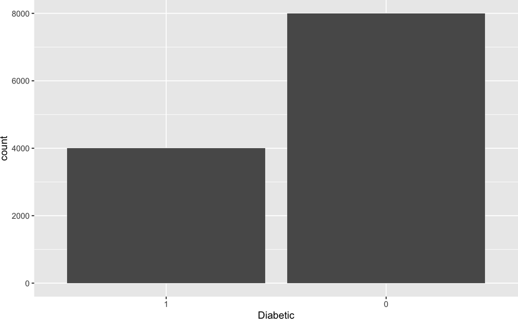

```r
diabetes_train %>%
  ggplot(aes(x = Diabetic)) +
  geom_bar()
```

A distribuição etária é semelhante entre as diabéticos e não diabéticos?

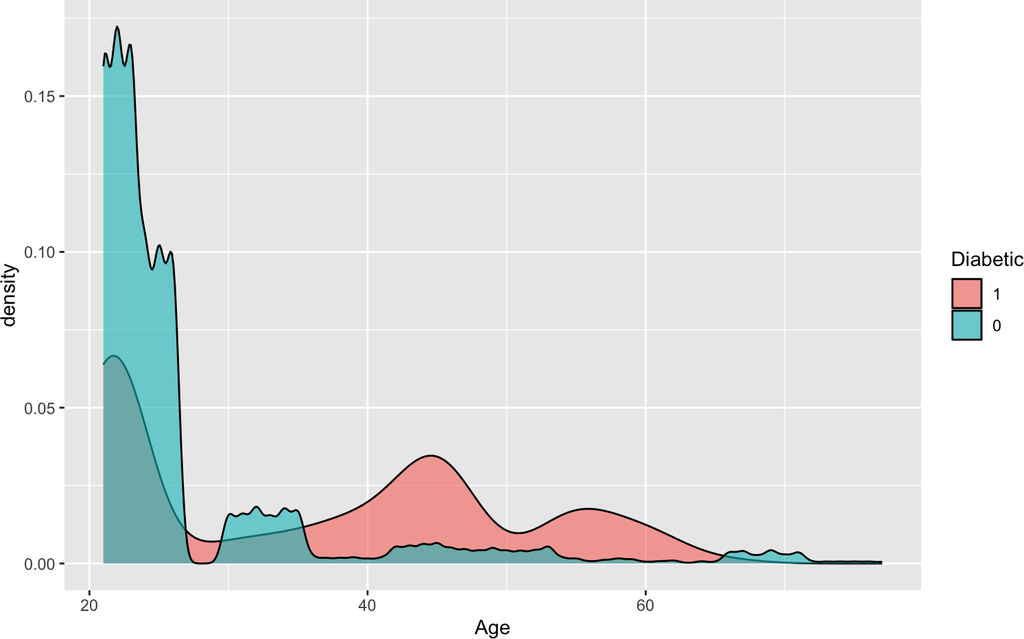

```r
diabetes_train %>%
  ggplot(aes(x = Age, fill = Diabetic, group = Diabetic)) +
  geom_density(position = "identity", alpha = .6)
```

A distribuição de `PlasmaGlucose` é semelhante entre as diabéticos e não diabéticos?

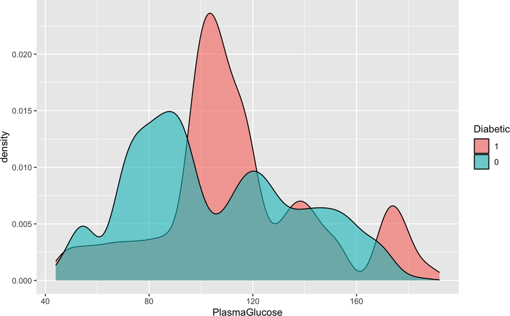

```r
diabetes_train %>%
  ggplot(aes(x = PlasmaGlucose, fill = Diabetic, group = Diabetic)) +
  geom_density(position = "identity", alpha = .6)
```

Podemos usar também boxplot para avaliar a distribuição de `BMI` entre diabéticos e não diabéticos:

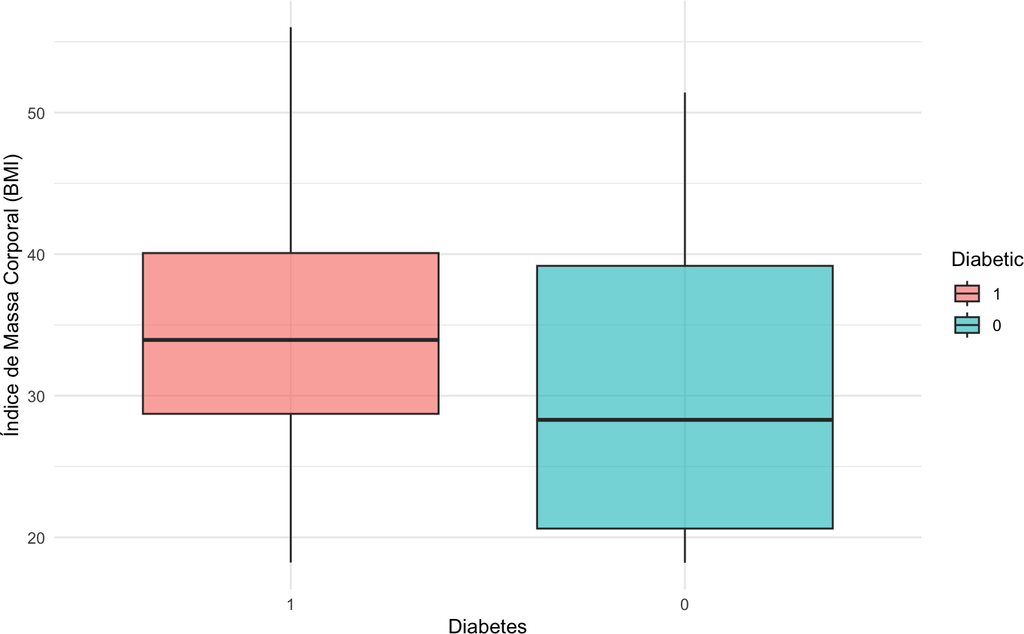

```r
diabetes_train %>%
  ggplot(aes(x = Diabetic, y = BMI, fill = Diabetic)) +
  geom_boxplot(alpha = 0.6) +
  labs(x = "Diabetes", y = "Índice de Massa Corporal (BMI)") +
  theme_minimal()
```

# 4 Modelo

No `tidymodels`, temos alguns passos para especificar um modelo:

1. Escolha um modelo (*model*)
2. Especifique um mecanismo (*engine*)
3. Defina o modo (*mode*)

Por exemplo, para especificar um modelo de regressão logística, usamos:

```r
logistic_reg()
```

```
## Logistic Regression Model Specification (classification)
##
## Computational engine: glm
```

Depois que a forma funcional do modelo é especificada, é necessário pensar em um mecanismo/método para ajustar ou treinar o modelo, chamado de *engine*.

```r
args(logistic_reg)
```

```
## function (mode = "classification", engine = "glm", penalty = NULL,
##     mixture = NULL)
## NULL
```

Aqui vemos que o método *default* para `logistic_reg()` é `glm` (modelos lineares generalizados), mas outros modelos também estão disponíveis.

Se quisermos ajustar um modelo de regressão logística via modelos lineares generalizados regularizados por *lasso* e *elastic-net*, podemos especificar através da *engine*:

```r
logistic_reg() %>%
   set_engine("glmnet")
```

```
## Logistic Regression Model Specification (classification)
##
## Computational engine: glmnet
```

Todos os modelos disponíveis estão listados no site: https://www.tidymodels.org/find/parsnip/

# 5 Receitas

[figure not shown]

Antes de proceder para o ajuste/treinamento do modelo, faz-se o pré-processamento dos dados, já que:

- Alguns **modelos** exigem que os preditores tenham certas características ou certos formatos.
- Algumas **variáveis** requerem algum tipo de transformação.

Para isso, o `tidymodels` usa o que é chamado de receita (`recipe`).

Uma primeira receita:

```r
rec_simple <- recipe(Diabetic ~ ., data = diabetes_train)
```

No exemplo acima, a função `recipe()` apenas define a variável resposta e os preditores através da fórmula.

```r
rec_simple %>% summary() %>% kable(booktabs = TRUE)
```

| variable | type | role | source |
| --- | --- | --- | --- |
| Pregnancies | double , numeric | predictor | original |
| PlasmaGlucose | double , numeric | predictor | original |
| DiastolicBloodPressure | double , numeric | predictor | original |
| TricepsThickness | double , numeric | predictor | original |
| SerumInsulin | double , numeric | predictor | original |
| BMI | double , numeric | predictor | original |
| DiabetesPedigree | double , numeric | predictor | original |
| Age | double , numeric | predictor | original |
| Diabetic | factor , unordered, nominal | outcome | original |

Os passos de pré-processamento de uma receita usam os dados de treinamento para os cálculos. Tipos de cálculos no processamento:

- Níveis de uma variável categórica
- Avaliar se uma coluna tem variância nula (constante) - `step_zv()`
- Calcular média e desvio-padrão para a normalização
- Projetar os novos dados nas componentes principais obtidas pelos dados de treinamento.

Um outro exemplo de receita:

```r
diabetes_rec <- recipe(Diabetic ~ ., data = diabetes_train) %>%
  step_poly(Age, degree = 2)
```

A tabela a seguir apresenta os dados pré-processamos segundo a receita acima:

| Diabetic | Pregnancies | PlasmaGlucose | DiastolicBloodPressure | TricepsThickness | SerumInsulin | BMI | DiabetesPedigree | Age_poly_1 | Age_poly_2 |
| --- | --- | --- | --- | --- | --- | --- | --- | --- | --- |
| 0 | 0 | 171 | 80 | 34 | 23 | 43.510 | 1.213 | -0.007 | 0.006 |
| 0 | 7 | 115 | 47 | 52 | 35 | 41.512 | 0.079 | -0.005 | 0.002 |
| 0 | 0 | 82 | 92 | 9 | 253 | 19.724 | 0.103 | -0.003 | -0.003 |
| 0 | 0 | 133 | 47 | 19 | 227 | 21.941 | 0.174 | -0.007 | 0.006 |
| 0 | 1 | 88 | 86 | 11 | 58 | 43.225 | 0.230 | -0.006 | 0.004 |
| 0 | 3 | 94 | 96 | 31 | 36 | 21.294 | 0.259 | -0.005 | 0.002 |
| 0 | 7 | 110 | 82 | 16 | 44 | 36.089 | 0.281 | -0.004 | -0.002 |
| 0 | 0 | 148 | 58 | 11 | 179 | 39.192 | 0.161 | 0.011 | -0.012 |
| 0 | 0 | 92 | 84 | 8 | 324 | 21.866 | 0.258 | 0.002 | -0.012 |
| 0 | 0 | 118 | 95 | 7 | 276 | 42.501 | 0.084 | -0.005 | 0.000 |

# 6 Workflow

Gerenciar um modelo especificado com o `parsnip` (`model` + `engine` + `mode`) e os passos de pré-processamento usando `recipes`, pode ser um desafio.

Para isso, o `tidymodels` propõe o uso da função `workflow()`, que possui dois argumentos opcionais:

- `preprocessor`: pode ser uma fórmula ou uma receita
- `spec`: modelo especificado com `parsnip`

Vamos especificar um modelo de regressão logística:

```r
logreg_spec <- logistic_reg() %>%
  set_engine("glm", family = "binomial") %>%
  set_mode("classification")
```

A receita a ser aplicada está no objeto `diabetes_rec`.

Vamos agregar essas duas informações no *workflow*:

```r
logreg_wf <- workflow(diabetes_rec, logreg_spec)
```

A função `fit()` pode ser usada para ajustar o modelo usando os dados de treinamento:

```r
logreg_fit <- logreg_wf %>% fit(data = diabetes_train)
logreg_fit
```

```
## ══ Workflow [trained] ══════════════════════════════════════════════════════════
## Preprocessor: Recipe
## Model: logistic_reg()
##
## ── Preprocessor ────────────────────────────────────────────────────────────────
## 1 Recipe Step
##
## • step_poly()
##
## ── Model ───────────────────────────────────────────────────────────────────────
##
## Call:  stats::glm(formula = ..y ~ ., family = ~"binomial", data = data)
##
## Coefficients:
##            (Intercept)             Pregnancies           PlasmaGlucose
##               6.928384               -0.278826               -0.008881
## DiastolicBloodPressure        TricepsThickness            SerumInsulin
##              -0.011326               -0.023160               -0.003905
##                    BMI        DiabetesPedigree              Age_poly_1
##              -0.052296               -0.987093              -79.422268
##             Age_poly_2
##              32.092675
##
## Degrees of Freedom: 11999 Total (i.e. Null);  11990 Residual
## Null Deviance:       15280
## Residual Deviance: 10280     AIC: 10300
```

A função `tidy()` do pacote `broom` resume as informações mais importantes de um modelo usando o conceito tidy:

```r
logreg_fit %>% tidy(conf.int = TRUE) %>%
  kable(booktabs = TRUE)
```

| term | estimate | std.error | statistic | p.value | conf.low | conf.high |
| --- | --- | --- | --- | --- | --- | --- |
| (Intercept) | 6.9283841 | 0.1918184 | 36.119500 | 0 | 6.5551673 | 7.3071513 |
| Pregnancies | -0.2788264 | 0.0075937 | -36.718150 | 0 | -0.2937908 | -0.2640212 |
| PlasmaGlucose | -0.0088807 | 0.0007768 | -11.432341 | 0 | -0.0104063 | -0.0073610 |
| DiastolicBloodPressure | -0.0113256 | 0.0014974 | -7.563761 | 0 | -0.0142655 | -0.0083954 |
| TricepsThickness | -0.0231602 | 0.0017118 | -13.529774 | 0 | -0.0265251 | -0.0198142 |
| SerumInsulin | -0.0039049 | 0.0001836 | -21.271690 | 0 | -0.0042664 | -0.0035467 |
| BMI | -0.0522958 | 0.0026186 | -19.971214 | 0 | -0.0574471 | -0.0471814 |
| DiabetesPedigree | -0.9870933 | 0.0632462 | -15.607145 | 0 | -1.1113740 | -0.8634180 |
| Age_poly_1 | -79.4222681 | 2.6000689 | -30.546217 | 0 | -84.5358127 | -74.3425722 |
| Age_poly_2 | 32.0926749 | 2.4744368 | 12.969689 | 0 | 27.2599637 | 36.9621785 |

```r
logreg_fit %>% tidy(conf.int = TRUE, exponentiate = TRUE) %>%
  kable(booktabs = TRUE)
```

| term | estimate | std.error | statistic | p.value | conf.low | conf.high |
| --- | --- | --- | --- | --- | --- | --- |
| (Intercept) | 1.020843e+03 | 0.1918184 | 36.119500 | 0 | 7.028667e+02 | 1.490924e+03 |
| Pregnancies | 7.566713e-01 | 0.0075937 | -36.718150 | 0 | 7.454324e-01 | 7.679573e-01 |
| PlasmaGlucose | 9.911586e-01 | 0.0007768 | -11.432341 | 0 | 9.896476e-01 | 9.926660e-01 |
| DiastolicBloodPressure | 9.887383e-01 | 0.0014974 | -7.563761 | 0 | 9.858358e-01 | 9.916398e-01 |
| TricepsThickness | 9.771059e-01 | 0.0017118 | -13.529774 | 0 | 9.738236e-01 | 9.803808e-01 |
| SerumInsulin | 9.961027e-01 | 0.0001836 | -21.271690 | 0 | 9.957427e-01 | 9.964596e-01 |
| BMI | 9.490481e-01 | 0.0026186 | -19.971214 | 0 | 9.441719e-01 | 9.539143e-01 |
| DiabetesPedigree | 3.726583e-01 | 0.0632462 | -15.607145 | 0 | 3.291065e-01 | 4.217182e-01 |
| Age_poly_1 | 0.000000e+00 | 2.6000689 | -30.546217 | 0 | 0.000000e+00 | 0.000000e+00 |
| Age_poly_2 | 8.663066e+13 | 2.4744368 | 12.969689 | 0 | 6.900043e+11 | 1.128418e+16 |

A função `predict()` calcula os valores preditos para o conjunto especificado:

```r
logreg_fit %>% predict(diabetes_train)
```

```
## # A tibble: 12,000 × 1
##    .pred_class
##    <fct>
##  1 0
##  2 0
##  3 0
##  4 0
##  5 0
##  6 0
##  7 0
##  8 0
##  9 0
## 10 0
## # ℹ 11,990 more rows
```

A predição com `tidymodels` garante que:

- as predições estarão sempre dentro de um dataframe/tibble;
- os nomes e tipos das colunas são previsíveis e intuitivas;
- o número de linhas em new_data e a saída são iguais.

Pode-se usar também a função `augment()`, que calcula os valores preditos, adicionando-os em uma coluna no conjunto de dados especificado:

```r
logreg_fit %>% augment(diabetes_train)
```

```
## # A tibble: 12,000 × 12
##    .pred_class .pred_1 .pred_0 Pregnancies PlasmaGlucose DiastolicBloodPressure
##    <fct>         <dbl>   <dbl>       <dbl>         <dbl>                  <dbl>
##  1 0            0.289    0.711           0           171                     80
##  2 0            0.420    0.580           7           115                     47
##  3 0            0.0490   0.951           0            82                     92
##  4 0            0.0350   0.965           0           133                     47
##  5 0            0.0730   0.927           1            88                     86
##  6 0            0.0806   0.919           3            94                     96
##  7 0            0.351    0.649           7           110                     82
##  8 0            0.372    0.628           0           148                     58
##  9 0            0.146    0.854           0            92                     84
## 10 0            0.164    0.836           0           118                     95
## # ℹ 11,990 more rows
## # ℹ 6 more variables: TricepsThickness <dbl>, SerumInsulin <dbl>, BMI <dbl>,
## #   DiabetesPedigree <dbl>, Age <dbl>, Diabetic <fct>
```

# 7 Avaliar e comparar modelos

Até aqui, fizemos o pré-processamento, definimos e treinamos o modelo escolhido usando os dados de treinamento.

## 7.1 Métricas

Como avaliar se o modelo tem bom desempenho (foco em predição)?

Olhar os resultados para cada observação não é produtivo:

```r
logreg_fit %>%
  augment(new_data = diabetes_train) %>%
  head()
```

```
## # A tibble: 6 × 12
##   .pred_class .pred_1 .pred_0 Pregnancies PlasmaGlucose DiastolicBloodPressure
##   <fct>         <dbl>   <dbl>       <dbl>         <dbl>                  <dbl>
## 1 0            0.289    0.711           0           171                     80
## 2 0            0.420    0.580           7           115                     47
## 3 0            0.0490   0.951           0            82                     92
## 4 0            0.0350   0.965           0           133                     47
## 5 0            0.0730   0.927           1            88                     86
## 6 0            0.0806   0.919           3            94                     96
## # ℹ 6 more variables: TricepsThickness <dbl>, SerumInsulin <dbl>, BMI <dbl>,
## #   DiabetesPedigree <dbl>, Age <dbl>, Diabetic <fct>
```

Temos algumas métricas para comparar os valores preditos com os observados (erro de predição):

Dentro de `tidymodels` temos a função `metrics()` do pacote `yardstick` para avaliar o modelo. Temos que especificar os seguintes argumentos em `metrics()`:

- `truth`: nome da variável com os valores observados da resposta
- `estimate`: nome da variável contendo os valores preditos

```r
logreg_fit %>%
  augment(new_data = diabetes_train) %>%
  metrics(truth = Diabetic, estimate = .pred_class) %>%
  kable(booktabs = TRUE)
```

| .metric | .estimator | .estimate |
| --- | --- | --- |
| accuracy | binary | 0.7974167 |
| kap | binary | 0.5262132 |

Podemos especificar apenas uma métrica:

```r
logreg_fit %>%
  augment(new_data = diabetes_train) %>%
  accuracy(truth = Diabetic, estimate = .pred_class) %>%
  kable(booktabs = TRUE)
```

| .metric | .estimator | .estimate |
| --- | --- | --- |
| accuracy | binary | 0.7974167 |

Matriz de confusão de treinamento:

```r
logreg_fit %>%
  augment(new_data = diabetes_train) %>%
  conf_mat(truth = Diabetic, estimate = .pred_class)
```

```
##           Truth
## Prediction    1    0
##          1 2481  912
##          0 1519 7088
```

Um gráfico ilustrando os resultados:

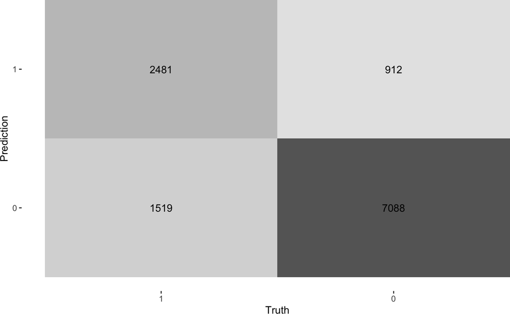

```r
logreg_fit %>%
  augment(new_data = diabetes_train) %>%
  conf_mat(truth = Diabetic, estimate = .pred_class) %>%
  autoplot(type = "heatmap")
```

Também é possível especificar um conjunto de métricas. No exemplo a seguir, `diabetes_metrics` é definido como um conjunto de três métricas de interesse:

```r
diabetes_metrics <- metric_set(accuracy, sensitivity, specificity)
```

E podemos avaliar este conjunto de métricas no modelo ajustado:

```r
augment(logreg_fit, new_data = diabetes_train) %>%
  diabetes_metrics(truth = Diabetic, estimate = .pred_class) %>%
  kable(booktabs = TRUE)
```

| .metric | .estimator | .estimate |
| --- | --- | --- |
| accuracy | binary | 0.7974167 |
| sensitivity | binary | 0.6202500 |
| specificity | binary | 0.8860000 |

Ao calcularmos as métricas tanto no conjunto de treinamento quanto no de teste, podemos avaliar se o modelo está super-ajustando (*overfitting*):

```r
logreg_fit %>%
  augment(diabetes_train) %>%
  metrics(truth = Diabetic, estimate = .pred_class)
```

```
## # A tibble: 2 × 3
##   .metric  .estimator .estimate
##   <chr>    <chr>          <dbl>
## 1 accuracy binary         0.797
## 2 kap      binary         0.526
```

```r
logreg_fit %>%
  augment(diabetes_test) %>%
  metrics(truth = Diabetic, estimate = .pred_class)
```

```
## # A tibble: 2 × 3
##   .metric  .estimator .estimate
##   <chr>    <chr>          <dbl>
## 1 accuracy binary         0.784
## 2 kap      binary         0.492
```

Essa métrica usa como corte a probabilidade `0.5` para declarar um evento (se a probabilidade estimada for acima de 0.5, declaramos Diabético = 1 e 0 caso contrário).

E se decidirmos definir o corte como `0.8`? A variação desse limite afeta as métricas de sensibilidade e especificidade.

Podemos usar a curva ROC (receiver operator characteristic):

- x-axis: taxa de falso positivo (1 - especificidade)
- y-axis: taxa de verdadeiro positivo (sensibilidade)

portanto, temos um cenário com sensibilidade e especificidade calculadas em todos os limites possíveis.

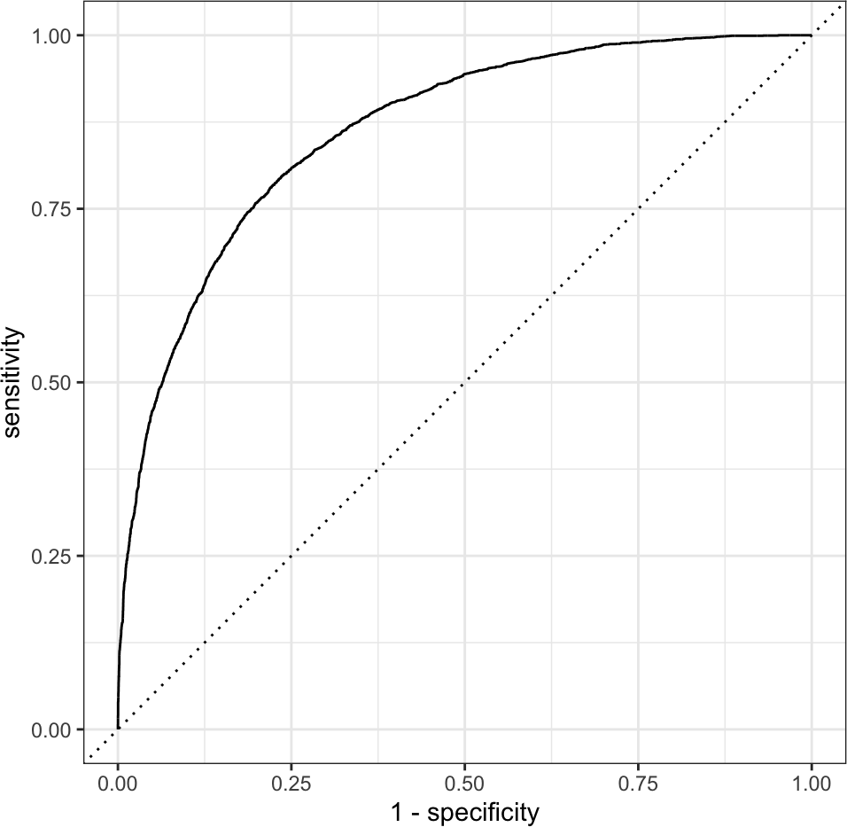

```r
augment(logreg_fit, new_data = diabetes_train) %>%
  roc_curve(truth = Diabetic, .pred_1) %>%
    autoplot()
```

A area sob a curva ROC pode ser usada como métrica:

```r
augment(logreg_fit, new_data = diabetes_train) %>%
  roc_auc(truth = Diabetic, .pred_1) %>%
  kable(booktabs = TRUE)
```

| .metric | .estimator | .estimate |
| --- | --- | --- |
| roc_auc | binary | 0.8625254 |

e podemos fixar algumas linhas para visualizar os valores de corte (`threshold`) e seus respectivos TPR e FPR:

```r
augment(logreg_fit, new_data = diabetes_train) %>%
  roc_curve(truth = Diabetic, .pred_1) %>%
  slice(1, 500, 1000, 2000, 4000, 6000, 8000, 10000) %>%
  kable(booktabs = TRUE)
```

| .threshold | specificity | sensitivity |
| --- | --- | --- |
| -Inf | 0.000000 | 1.00000 |
| 0.0242410 | 0.062000 | 0.99950 |
| 0.0348151 | 0.124000 | 0.99850 |
| 0.0561580 | 0.244750 | 0.99000 |
| 0.1150272 | 0.474625 | 0.94975 |
| 0.2254710 | 0.678875 | 0.85825 |
| 0.4256154 | 0.846750 | 0.69400 |
| 0.6936874 | 0.959375 | 0.41925 |

## 7.2 Validação Cruzada

Usaremos 5 *folds* como exemplo. Para reamostrar os dados de treino, usaremos o comando `vfold_cv`:

```r
set.seed(234)
diabetes_folds <- diabetes_train %>%
                vfold_cv(v = 5, strata = Diabetic)
diabetes_folds
```

```
## #  5-fold cross-validation using stratification
## # A tibble: 5 × 2
##   splits              id
##   <list>              <chr>
## 1 <split [9600/2400]> Fold1
## 2 <split [9600/2400]> Fold2
## 3 <split [9600/2400]> Fold3
## 4 <split [9600/2400]> Fold4
## 5 <split [9600/2400]> Fold5
```

Ajustando o modelo nas reamostragens:

```r
logreg_cv <- logreg_wf %>% fit_resamples(diabetes_folds)
logreg_cv
```

```
## # Resampling results
## # 5-fold cross-validation using stratification
## # A tibble: 5 × 4
##   splits              id    .metrics         .notes
##   <list>              <chr> <list>           <list>
## 1 <split [9600/2400]> Fold1 <tibble [3 × 4]> <tibble [0 × 4]>
## 2 <split [9600/2400]> Fold2 <tibble [3 × 4]> <tibble [0 × 4]>
## 3 <split [9600/2400]> Fold3 <tibble [3 × 4]> <tibble [0 × 4]>
## 4 <split [9600/2400]> Fold4 <tibble [3 × 4]> <tibble [0 × 4]>
## 5 <split [9600/2400]> Fold5 <tibble [3 × 4]> <tibble [0 × 4]>
```

A função `collect_metrics()` extrai as métricas obtidas em cada reamostra e calcula a métrica da validação, geralmente através de uma média:

```r
logreg_cv %>%
  collect_metrics() %>%
  kable(booktabs = TRUE)
```

| .metric | .estimator | mean | n | std_err | .config |
| --- | --- | --- | --- | --- | --- |
| accuracy | binary | 0.7965833 | 5 | 0.0021707 | pre0_mod0_post0 |
| brier_class | binary | 0.1391407 | 5 | 0.0009101 | pre0_mod0_post0 |
| roc_auc | binary | 0.8618658 | 5 | 0.0015880 | pre0_mod0_post0 |

Para calcular um conjunto escolhido de métricas, é preciso especificar o conjunto no argumento `metrics` dentro de `fit_resamples`:

```r
logreg_cv <- fit_resamples(logreg_wf,
                 diabetes_folds,
                 metrics = diabetes_metrics)

logreg_cv %>%
  collect_metrics() %>%
  kable(booktabs = TRUE)
```

| .metric | .estimator | mean | n | std_err | .config |
| --- | --- | --- | --- | --- | --- |
| accuracy | binary | 0.7965833 | 5 | 0.0021707 | pre0_mod0_post0 |
| sensitivity | binary | 0.6180000 | 5 | 0.0054715 | pre0_mod0_post0 |
| specificity | binary | 0.8858750 | 5 | 0.0025890 | pre0_mod0_post0 |

Através da validação cruzada, avaliamos o desempenho do modelo apenas com os dados de treinamento, sem usar os dados de teste.

A métrica obtida no conjunto de validação pode ser tomada como uma estimativa da métrica no conjunto de teste.

Caso seja necessário salvar as predições obtidas nas etapas de validação cruzada, para fazer um gráfico, por exemplo, usamos `control_resamples`:

```r
ctrl_malaria <- control_resamples(save_pred = TRUE)

logreg_cv <- fit_resamples(logreg_wf,
               diabetes_folds,
               control = ctrl_malaria)

logreg_preds <- collect_predictions(logreg_cv)
logreg_preds
```

```
## # A tibble: 12,000 × 7
##    .pred_class .pred_1 .pred_0 id    Diabetic  .row .config
##    <fct>         <dbl>   <dbl> <chr> <fct>    <int> <chr>
##  1 0            0.0735   0.927 Fold1 0            5 pre0_mod0_post0
##  2 0            0.305    0.695 Fold1 0           20 pre0_mod0_post0
##  3 0            0.109    0.891 Fold1 0           24 pre0_mod0_post0
##  4 0            0.362    0.638 Fold1 0           37 pre0_mod0_post0
##  5 0            0.0716   0.928 Fold1 0           41 pre0_mod0_post0
##  6 0            0.148    0.852 Fold1 0           44 pre0_mod0_post0
##  7 0            0.0791   0.921 Fold1 0           47 pre0_mod0_post0
##  8 0            0.360    0.640 Fold1 0           49 pre0_mod0_post0
##  9 0            0.0798   0.920 Fold1 0           50 pre0_mod0_post0
## 10 0            0.280    0.720 Fold1 0           67 pre0_mod0_post0
## # ℹ 11,990 more rows
```

## 7.3 Árvore de decisão

Um outro modelo a ser considerado é árvore de decisão. Vamos considerar o seguinte exemplo:

```r
tree_spec <- decision_tree(cost_complexity = 0.005) %>%
    set_mode("classification") %>%
    set_engine("rpart", model = TRUE)
tree_spec
```

```
## Decision Tree Model Specification (classification)
##
## Main Arguments:
##   cost_complexity = 0.005
##
## Engine-Specific Arguments:
##   model = TRUE
##
## Computational engine: rpart
```

O modelo de árvore de decisão não requer pré-processamento, de forma que podemos usar um `workflow` com a fórmula e o modelo especificado, por exemplo:

```r
tree_wf <- workflow(Diabetic ~ ., tree_spec)
tree_wf
```

```
## ══ Workflow ════════════════════════════════════════════════════════════════════
## Preprocessor: Formula
## Model: decision_tree()
##
## ── Preprocessor ────────────────────────────────────────────────────────────────
## Diabetic ~ .
##
## ── Model ───────────────────────────────────────────────────────────────────────
## Decision Tree Model Specification (classification)
##
## Main Arguments:
##   cost_complexity = 0.005
##
## Engine-Specific Arguments:
##   model = TRUE
##
## Computational engine: rpart
```

E ajustar com os dados de treinamento:

```r
tree_fit <- tree_wf %>% fit(data = diabetes_train)
```

Visualização do modelo ajustado:

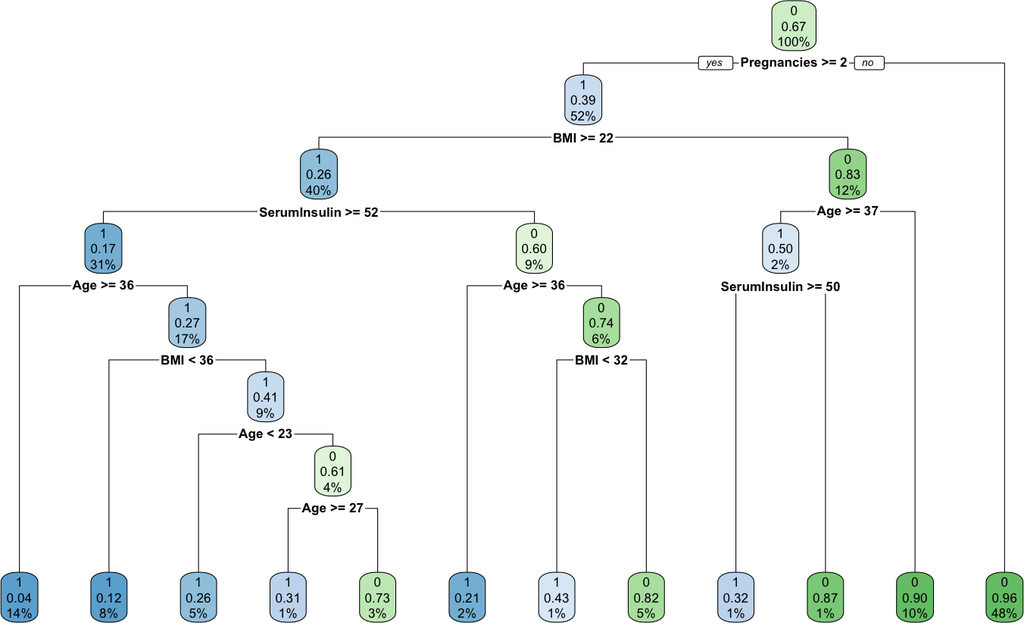

```r
library(rpart.plot)

tree_fit %>%
  extract_fit_engine() %>%
  rpart.plot()
```

Vamos então avaliar o desempenho da árvore de decisão através da validação cruzada:

```r
tree_cv <- tree_wf %>% fit_resamples(diabetes_folds)

tree_cv %>% collect_metrics() %>%
  kable(booktabs = TRUE)
```

| .metric | .estimator | mean | n | std_err | .config |
| --- | --- | --- | --- | --- | --- |
| accuracy | binary | 0.9050833 | 5 | 0.0019913 | pre0_mod0_post0 |
| brier_class | binary | 0.0784368 | 5 | 0.0014673 | pre0_mod0_post0 |
| roc_auc | binary | 0.9335519 | 5 | 0.0022146 | pre0_mod0_post0 |

## 7.4 Floresta Aleatória

Podemos também considerar um modelo de floresta aleatória.

Aqui, usaremos `set_engine` e adicionaremos o argumento `importance = "impurity"`, para que possamos ter pontuações de importância variáveis, para avaliarmos quais preditores são mais relevantes.

```r
rf_spec <- rand_forest(trees = 1000) %>%
    set_mode("classification") %>%
    set_engine("ranger", importance = "impurity")
rf_spec
```

```
## Random Forest Model Specification (classification)
##
## Main Arguments:
##   trees = 1000
##
## Engine-Specific Arguments:
##   importance = impurity
##
## Computational engine: ranger
```

Um `workflow` simples:

```r
rf_wf <- workflow(Diabetic ~ ., rf_spec)
rf_wf
```

```
## ══ Workflow ════════════════════════════════════════════════════════════════════
## Preprocessor: Formula
## Model: rand_forest()
##
## ── Preprocessor ────────────────────────────────────────────────────────────────
## Diabetic ~ .
##
## ── Model ───────────────────────────────────────────────────────────────────────
## Random Forest Model Specification (classification)
##
## Main Arguments:
##   trees = 1000
##
## Engine-Specific Arguments:
##   importance = impurity
##
## Computational engine: ranger
```

Avaliação das métricas usando validação cruzada:

```r
set.seed(2024) #RF uses random numbers, so we need to set the seed
rf_cv <- rf_wf %>%
  fit_resamples(diabetes_folds)

rf_cv %>% collect_metrics() %>%
  kable(booktabs = TRUE)
```

| .metric | .estimator | mean | n | std_err | .config |
| --- | --- | --- | --- | --- | --- |
| accuracy | binary | 0.9380000 | 5 | 0.0022024 | pre0_mod0_post0 |
| brier_class | binary | 0.0486464 | 5 | 0.0008969 | pre0_mod0_post0 |
| roc_auc | binary | 0.9826511 | 5 | 0.0008106 | pre0_mod0_post0 |

## 7.5 Conjunto de modelos

Quando queremos comparar vários modelos ao mesmo tempo, é muito trabalhoso fazer um de cada vez, como mostramos anteriormente.

`tidymodels` se mostra útil também nesta tarefa. Primeiro, podemos usar a função `workflow_set()` para gerar um conjunto de *workflows* que desejamos avaliar. Os argumentos desta função são:

- `preproc`: formulas, recipes
- `models`: models specified using `parsnip`

Aqui, definimos um conjunto de *workflows* de interesse:

```r
wf_set <- workflow_set(preproc = list(rec1 = Diabetic ~ .,
                                      rec2 = diabetes_rec,
                                      rec1 = Diabetic ~ .),
                       models = list(tree = tree_spec,
                                     logreg = logreg_spec,
                                     rf = rf_spec),
                       cross = FALSE)
```

Para processar este conjunto de *workflows*, usamos a função `workflow_map()`. Podemos avaliar os modelos com as métricas desejadas usando a validação cruzada usando `fit_resamples`:

```r
wf_set %>%
  workflow_map("fit_resamples",
               resamples = diabetes_folds,
               metrics = diabetes_metrics,
               seed = 2024) %>%
  rank_results()
```

```
## # A tibble: 9 × 9
##   wflow_id    .config       .metric  mean std_err     n preprocessor model  rank
##   <chr>       <chr>         <chr>   <dbl>   <dbl> <int> <chr>        <chr> <int>
## 1 rec1_rf     pre0_mod0_po… accura… 0.938 0.00220     5 formula      rand…     1
## 2 rec1_rf     pre0_mod0_po… sensit… 0.892 0.00214     5 formula      rand…     1
## 3 rec1_rf     pre0_mod0_po… specif… 0.961 0.00391     5 formula      rand…     1
## 4 rec1_tree   pre0_mod0_po… accura… 0.905 0.00199     5 formula      deci…     2
## 5 rec1_tree   pre0_mod0_po… sensit… 0.859 0.00805     5 formula      deci…     2
## 6 rec1_tree   pre0_mod0_po… specif… 0.928 0.00447     5 formula      deci…     2
## 7 rec2_logreg pre0_mod0_po… accura… 0.797 0.00217     5 recipe       logi…     3
## 8 rec2_logreg pre0_mod0_po… sensit… 0.618 0.00547     5 recipe       logi…     3
## 9 rec2_logreg pre0_mod0_po… specif… 0.886 0.00259     5 recipe       logi…     3
```

Se o argumento `cross = TRUE` o `workflow_set` faz um produto cruzado das receitas e modelos:

```r
workflow_set(preproc = list(rec1 = Diabetic ~ .,
                            rec2 = diabetes_rec),
             models = list(tree = tree_spec,
                           logreg = logreg_spec,
                           rf = rf_spec),
             cross = TRUE) %>%
  workflow_map("fit_resamples",
               resamples = diabetes_folds,
               metrics = diabetes_metrics,
               seed = 2024) %>%
  rank_results()
```

```
## # A tibble: 18 × 9
##    wflow_id    .config      .metric  mean std_err     n preprocessor model  rank
##    <chr>       <chr>        <chr>   <dbl>   <dbl> <int> <chr>        <chr> <int>
##  1 rec1_rf     pre0_mod0_p… accura… 0.938 0.00220     5 formula      rand…     1
##  2 rec1_rf     pre0_mod0_p… sensit… 0.892 0.00214     5 formula      rand…     1
##  3 rec1_rf     pre0_mod0_p… specif… 0.961 0.00391     5 formula      rand…     1
##  4 rec2_rf     pre0_mod0_p… accura… 0.938 0.00254     5 recipe       rand…     2
##  5 rec2_rf     pre0_mod0_p… sensit… 0.899 0.00234     5 recipe       rand…     2
##  6 rec2_rf     pre0_mod0_p… specif… 0.957 0.00422     5 recipe       rand…     2
##  7 rec1_tree   pre0_mod0_p… accura… 0.905 0.00199     5 formula      deci…     3
##  8 rec1_tree   pre0_mod0_p… sensit… 0.859 0.00805     5 formula      deci…     3
##  9 rec1_tree   pre0_mod0_p… specif… 0.928 0.00447     5 formula      deci…     3
## 10 rec2_tree   pre0_mod0_p… accura… 0.905 0.00199     5 recipe       deci…     4
## 11 rec2_tree   pre0_mod0_p… sensit… 0.859 0.00805     5 recipe       deci…     4
## 12 rec2_tree   pre0_mod0_p… specif… 0.928 0.00447     5 recipe       deci…     4
## 13 rec2_logreg pre0_mod0_p… accura… 0.797 0.00217     5 recipe       logi…     5
## 14 rec2_logreg pre0_mod0_p… sensit… 0.618 0.00547     5 recipe       logi…     5
## 15 rec2_logreg pre0_mod0_p… specif… 0.886 0.00259     5 recipe       logi…     5
## 16 rec1_logreg pre0_mod0_p… accura… 0.789 0.00109     5 formula      logi…     6
## 17 rec1_logreg pre0_mod0_p… sensit… 0.603 0.00617     5 formula      logi…     6
## 18 rec1_logreg pre0_mod0_p… specif… 0.883 0.002       5 formula      logi…     6
```

Suponha que o modelo de regressão logística tenha sido o escolhido.

Vamos ajustar o modelo nos dados de treinamento e verificar o desempenho nos dados de teste.

```r
final_fit <- last_fit(logreg_wf,
                      diabetes_split,
                      metrics = diabetes_metrics)
```

Lembre-se que o objeto `diabetes_split` tem informações sobre a separação dos dados originais em treino e teste.

```r
final_fit
```

```
## # Resampling results
## # Manual resampling
## # A tibble: 1 × 6
##   splits               id              .metrics .notes   .predictions .workflow
##   <list>               <chr>           <list>   <list>   <list>       <list>
## 1 <split [12000/3000]> train/test spl… <tibble> <tibble> <tibble>     <workflow>
```

Métricas calculadas para o conjunto de dados **teste**:

```r
collect_metrics(final_fit)
```

```
## # A tibble: 3 × 4
##   .metric     .estimator .estimate .config
##   <chr>       <chr>          <dbl> <chr>
## 1 accuracy    binary         0.784 pre0_mod0_post0
## 2 sensitivity binary         0.59  pre0_mod0_post0
## 3 specificity binary         0.880 pre0_mod0_post0
```

Predições para o conjunto de dados **teste**:

```r
collect_predictions(final_fit) %>%
  head()
```

```
## # A tibble: 6 × 5
##   .pred_class id               Diabetic  .row .config
##   <fct>       <chr>            <fct>    <int> <chr>
## 1 0           train/test split 0            2 pre0_mod0_post0
## 2 0           train/test split 0            5 pre0_mod0_post0
## 3 0           train/test split 0            8 pre0_mod0_post0
## 4 0           train/test split 0           10 pre0_mod0_post0
## 5 1           train/test split 1           13 pre0_mod0_post0
## 6 0           train/test split 0           19 pre0_mod0_post0
```

Quais informações temos em `final_fit`?

```r
extract_workflow(final_fit)
```

```
## ══ Workflow [trained] ══════════════════════════════════════════════════════════
## Preprocessor: Recipe
## Model: logistic_reg()
##
## ── Preprocessor ────────────────────────────────────────────────────────────────
## 1 Recipe Step
##
## • step_poly()
##
## ── Model ───────────────────────────────────────────────────────────────────────
##
## Call:  stats::glm(formula = ..y ~ ., family = ~"binomial", data = data)
##
## Coefficients:
##            (Intercept)             Pregnancies           PlasmaGlucose
##               6.928384               -0.278826               -0.008881
## DiastolicBloodPressure        TricepsThickness            SerumInsulin
##              -0.011326               -0.023160               -0.003905
##                    BMI        DiabetesPedigree              Age_poly_1
##              -0.052296               -0.987093              -79.422268
##             Age_poly_2
##              32.092675
##
## Degrees of Freedom: 11999 Total (i.e. Null);  11990 Residual
## Null Deviance:       15280
## Residual Deviance: 10280     AIC: 10300
```

Quais as estimativas dos parâmetros do modelo final?

```r
final_fit %>%
  extract_fit_parsnip() %>%
  tidy()
```

```
## # A tibble: 10 × 5
##    term                    estimate std.error statistic   p.value
##    <chr>                      <dbl>     <dbl>     <dbl>     <dbl>
##  1 (Intercept)              6.93     0.192        36.1  1.12e-285
##  2 Pregnancies             -0.279    0.00759     -36.7  3.75e-295
##  3 PlasmaGlucose           -0.00888  0.000777    -11.4  2.88e- 30
##  4 DiastolicBloodPressure  -0.0113   0.00150      -7.56 3.92e- 14
##  5 TricepsThickness        -0.0232   0.00171     -13.5  1.04e- 41
##  6 SerumInsulin            -0.00390  0.000184    -21.3  2.08e-100
##  7 BMI                     -0.0523   0.00262     -20.0  9.80e- 89
##  8 DiabetesPedigree        -0.987    0.0632      -15.6  6.51e- 55
##  9 Age_poly_1             -79.4      2.60        -30.5  6.35e-205
## 10 Age_poly_2              32.1      2.47         13.0  1.82e- 38
```

# 8 Hiperparâmetros (*tuning*)

Algumas características dos modelos não podem ser estimadas diretamente dos dados.

Escolhemos um modelo de regressão logística, por exemplo, e usamos os dados de treinamento para obter os parâmetros do modelo.

No entanto, algumas escolhas são feitas antes do ajuste do modelo: usaremos alguma forma quadrática? interações? quais variáveis vamos considerar?

Algumas decisões devem ser feitas na etapa *receita* e outras devem ser feitas *dentro do modelo*.

Para ajuste fino, podemos testar *workflows* diferentes e avaliar o desempenho com validação cruzada.

## 8.1 Regressão logística com polinômio

Para um modelo de regressão logística em que uma das variáveis, `Age`, será considerada através de um polinômio, temos a seguinte receita:

```r
diabetes_rec <-
  recipe(Diabetic ~ ., data = diabetes_train) %>%
  step_poly(Age, degree = tune())
```

Repare que, acima, não especificamos diretamente o grau do polinômio. Vamos escolher o melhor hiperparâmetro usando a função `tune()`.

Com a receita definida, vamos agregar as informações:

```r
logregpol_wf <- workflow(diabetes_rec, logreg_spec)
logregpol_wf
```

```
## ══ Workflow ════════════════════════════════════════════════════════════════════
## Preprocessor: Recipe
## Model: logistic_reg()
##
## ── Preprocessor ────────────────────────────────────────────────────────────────
## 1 Recipe Step
##
## • step_poly()
##
## ── Model ───────────────────────────────────────────────────────────────────────
## Logistic Regression Model Specification (classification)
##
## Engine-Specific Arguments:
##   family = binomial
##
## Computational engine: glm
```

A função `tune_grid()` calcula um conjunto de métricas usando validação cruzada para avaliar o desempenho em um conjunto pré-determinado de hiperparâmetros de um modelo ou de uma receita:

```r
logregpol_res <- tune_grid(logregpol_wf,
                           diabetes_folds,
                           grid = tibble(degree=1:5))
logregpol_res
```

```
## # Tuning results
## # 5-fold cross-validation using stratification
## # A tibble: 5 × 4
##   splits              id    .metrics          .notes
##   <list>              <chr> <list>            <list>
## 1 <split [9600/2400]> Fold1 <tibble [15 × 5]> <tibble [1 × 4]>
## 2 <split [9600/2400]> Fold2 <tibble [15 × 5]> <tibble [1 × 4]>
## 3 <split [9600/2400]> Fold3 <tibble [15 × 5]> <tibble [1 × 4]>
## 4 <split [9600/2400]> Fold4 <tibble [15 × 5]> <tibble [1 × 4]>
## 5 <split [9600/2400]> Fold5 <tibble [15 × 5]> <tibble [1 × 4]>
##
## There were issues with some computations:
##
##   - Warning(s) x5: glm.fit: fitted probabilities numerically 0 or 1 occurred
##
## Run `show_notes(.Last.tune.result)` for more information.
```

Apresentando os resultados (média dos 5 *folds*) para cada grau de polinômio (hiperparâmetro) considerado:

```r
collect_metrics(logregpol_res)
```

```
## # A tibble: 15 × 7
##    degree .metric     .estimator  mean     n  std_err .config
##     <int> <chr>       <chr>      <dbl> <int>    <dbl> <chr>
##  1      1 accuracy    binary     0.789     5 0.00109  pre1_mod0_post0
##  2      1 brier_class binary     0.142     5 0.000820 pre1_mod0_post0
##  3      1 roc_auc     binary     0.860     5 0.00144  pre1_mod0_post0
##  4      2 accuracy    binary     0.797     5 0.00217  pre2_mod0_post0
##  5      2 brier_class binary     0.139     5 0.000910 pre2_mod0_post0
##  6      2 roc_auc     binary     0.862     5 0.00159  pre2_mod0_post0
##  7      3 accuracy    binary     0.814     5 0.00254  pre3_mod0_post0
##  8      3 brier_class binary     0.127     5 0.00168  pre3_mod0_post0
##  9      3 roc_auc     binary     0.889     5 0.00244  pre3_mod0_post0
## 10      4 accuracy    binary     0.818     5 0.00253  pre4_mod0_post0
## 11      4 brier_class binary     0.124     5 0.00187  pre4_mod0_post0
## 12      4 roc_auc     binary     0.894     5 0.00273  pre4_mod0_post0
## 13      5 accuracy    binary     0.830     5 0.00285  pre5_mod0_post0
## 14      5 brier_class binary     0.118     5 0.00138  pre5_mod0_post0
## 15      5 roc_auc     binary     0.902     5 0.00208  pre5_mod0_post0
```

Visualização gráfica usando `autoplot()`:

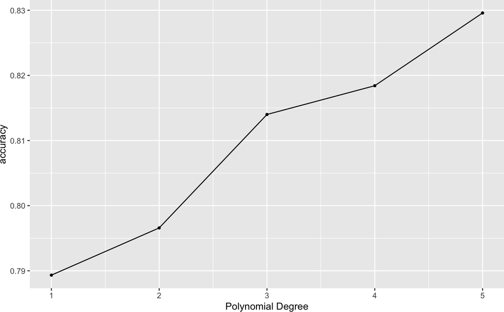

```r
autoplot(logregpol_res, metric = "accuracy")
```

Mostrando os melhores resultados:

```r
show_best(logregpol_res,
          metric = "accuracy",
          n = 3)
```

```
## # A tibble: 3 × 7
##   degree .metric  .estimator  mean     n std_err .config
##    <int> <chr>    <chr>      <dbl> <int>   <dbl> <chr>
## 1      5 accuracy binary     0.830     5 0.00285 pre5_mod0_post0
## 2      4 accuracy binary     0.818     5 0.00253 pre4_mod0_post0
## 3      3 accuracy binary     0.814     5 0.00254 pre3_mod0_post0
```

E se ajustarmos um outro modelo, também com algum outro hiperparâmetro? Como comparar?

## 8.2 LASSO

Podemos ajustar uma regressão logística com regularização LASSO:

```r
logreglasso_spec <- logistic_reg(penalty = tune(), mixture = 1) %>%
  set_engine("glmnet", family = "binomial") %>%
  set_mode("classification")
```

`mixture = 1` especifica LASSO puro e o hiperparâmetro `penalty` será escolhido (ajuste fino) através da validação cruzada.

Não consideraremos o polinômio para `Age` neste *workflow*, então podemos configurá-lo diretamente com a fórmula e o modelo especificado:

```r
logreglasso_wf <- workflow(Diabetic ~ ., logreglasso_spec)
logreglasso_wf
```

```
## ══ Workflow ════════════════════════════════════════════════════════════════════
## Preprocessor: Formula
## Model: logistic_reg()
##
## ── Preprocessor ────────────────────────────────────────────────────────────────
## Diabetic ~ .
##
## ── Model ───────────────────────────────────────────────────────────────────────
## Logistic Regression Model Specification (classification)
##
## Main Arguments:
##   penalty = tune()
##   mixture = 1
##
## Engine-Specific Arguments:
##   family = binomial
##
## Computational engine: glmnet
```

Para avaliar o desempenho de múltiplos valores do hiperparâmetro usando validação cruzada:

```r
set.seed(2024)
logreglasso_res <-
  tune_grid(logreglasso_wf,
            resamples = diabetes_folds,
            grid = 20,
            metrics = diabetes_metrics)
```

Métricas resultantes da validação cruzada considerando os valores do *grid*:

```r
logreglasso_res %>% collect_metrics()
```

```
## # A tibble: 60 × 7
##     penalty .metric     .estimator  mean     n std_err .config
##       <dbl> <chr>       <chr>      <dbl> <int>   <dbl> <chr>
##  1 1.29e-10 accuracy    binary     0.789     5 0.00107 pre0_mod01_post0
##  2 1.29e-10 sensitivity binary     0.6       5 0.00597 pre0_mod01_post0
##  3 1.29e-10 specificity binary     0.883     5 0.00189 pre0_mod01_post0
##  4 2.37e- 9 accuracy    binary     0.789     5 0.00107 pre0_mod02_post0
##  5 2.37e- 9 sensitivity binary     0.6       5 0.00597 pre0_mod02_post0
##  6 2.37e- 9 specificity binary     0.883     5 0.00189 pre0_mod02_post0
##  7 4.73e- 8 accuracy    binary     0.789     5 0.00107 pre0_mod03_post0
##  8 4.73e- 8 sensitivity binary     0.6       5 0.00597 pre0_mod03_post0
##  9 4.73e- 8 specificity binary     0.883     5 0.00189 pre0_mod03_post0
## 10 1.99e- 7 accuracy    binary     0.789     5 0.00107 pre0_mod04_post0
## # ℹ 50 more rows
```

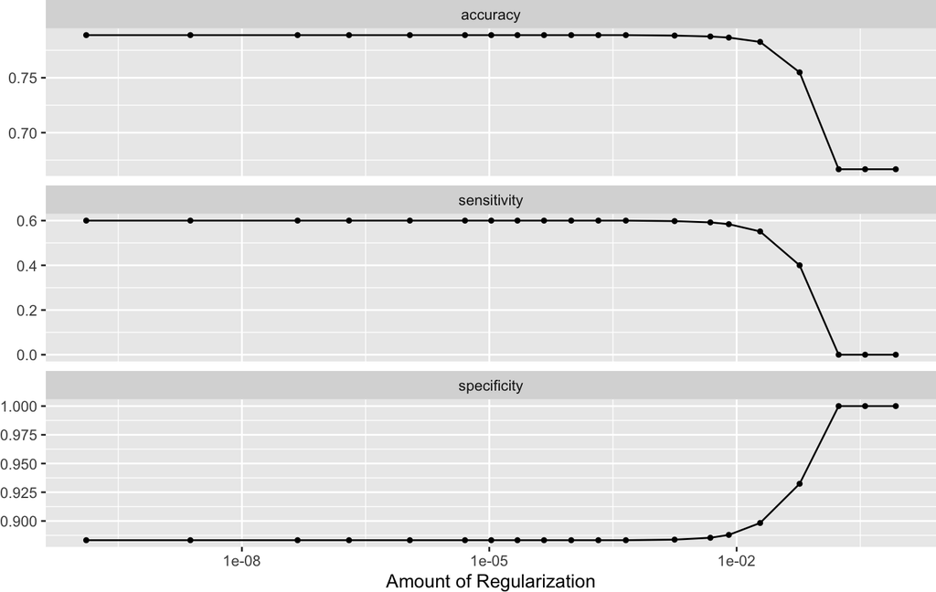

```r
autoplot(logreglasso_res)
```

O melhor resultado da validação cruzada, considerando a métrica de precisão:

```r
show_best(logreglasso_res, metric = "accuracy", n = 1)
```

```
## # A tibble: 1 × 7
##    penalty .metric  .estimator  mean     n std_err .config
##      <dbl> <chr>    <chr>      <dbl> <int>   <dbl> <chr>
## 1 1.29e-10 accuracy binary     0.789     5 0.00107 pre0_mod01_post0
```

## 8.3 Árvore de decisão

Abaixo está um *workflow* para uma árvore de decisão com ajuste de hiperparâmetro (`cost_complexity`). Primeiramente, o modelo é especificado incluindo `tune()`:

```r
tree_spec <-
  decision_tree(
    cost_complexity = tune()
  ) %>%
  set_mode("classification") %>%
  set_engine("rpart", model = TRUE)
```

O *workflow*:

```r
tree_wf <- workflow(Diabetic ~ ., tree_spec)
```

Vamos usar `tune_grid()` para avaliar múltiplos valores para o hiperparâmetro:

```r
tree_res <-
  tune_grid(tree_wf,
            resamples = diabetes_folds,
            grid = 30,
            metrics = diabetes_metrics)
```

É possível fornecer um `data.frame` na opção `grid`, para ser mais específico.

Métricas obtidas por meio de validação cruzada considerando os valores da `grade`:

```r
tree_res %>% collect_metrics()
```

```
## # A tibble: 90 × 7
##    cost_complexity .metric     .estimator  mean     n std_err .config
##              <dbl> <chr>       <chr>      <dbl> <int>   <dbl> <chr>
##  1        1.69e-10 accuracy    binary     0.913     5 0.00159 pre0_mod01_post0
##  2        1.69e-10 sensitivity binary     0.869     5 0.00393 pre0_mod01_post0
##  3        1.69e-10 specificity binary     0.935     5 0.00306 pre0_mod01_post0
##  4        5.04e-10 accuracy    binary     0.913     5 0.00159 pre0_mod02_post0
##  5        5.04e-10 sensitivity binary     0.869     5 0.00393 pre0_mod02_post0
##  6        5.04e-10 specificity binary     0.935     5 0.00306 pre0_mod02_post0
##  7        1.02e- 9 accuracy    binary     0.913     5 0.00159 pre0_mod03_post0
##  8        1.02e- 9 sensitivity binary     0.869     5 0.00393 pre0_mod03_post0
##  9        1.02e- 9 specificity binary     0.935     5 0.00306 pre0_mod03_post0
## 10        3.10e- 9 accuracy    binary     0.913     5 0.00159 pre0_mod04_post0
## # ℹ 80 more rows
```

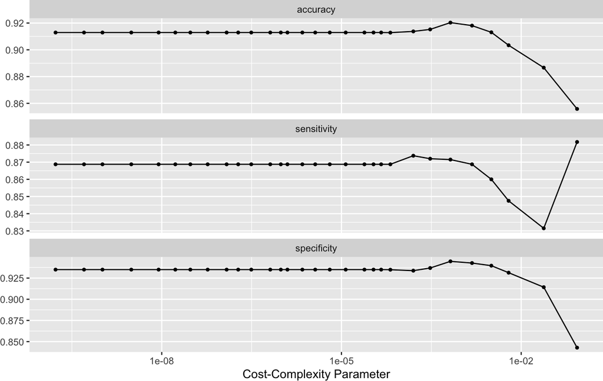

```r
autoplot(tree_res)
```

O melhor resultado da validação cruzada, considerando a métrica de acurácia:

```r
show_best(tree_res, metric = "accuracy", n = 1)
```

```
## # A tibble: 1 × 7
##   cost_complexity .metric  .estimator  mean     n std_err .config
##             <dbl> <chr>    <chr>      <dbl> <int>   <dbl> <chr>
## 1        0.000659 accuracy binary     0.920     5 0.00143 pre0_mod25_post0
```

## 8.4 Floresta aleatória

Um hiperparâmetro comumente escolhido para modelos de floresta aleatória é `mtry`, que é o número de preditores que serão amostrados aleatoriamente em cada bifurcação ao criar os modelos de árvore.

Quando usamos o `engine` (algoritmo/método) `ranger`, o [default](https://parsnip.tidymodels.org/reference/details_rand_forest_ranger.html) é `floor(sqrt(ncol(x)))`.

Vamos usar a validação cruzada para fazer o “ajuste fino” desse hiperparâmetro.

Começamos especificando o modelo e incluindo `tune()`:

```r
rf_spec <- rand_forest(trees = 1000,
                       mtry = tune()) %>%
    set_mode("classification") %>%
    set_engine("ranger", importance = "impurity")
rf_spec
```

```
## Random Forest Model Specification (classification)
##
## Main Arguments:
##   mtry = tune()
##   trees = 1000
##
## Engine-Specific Arguments:
##   importance = impurity
##
## Computational engine: ranger
```

O *workflow*:

```r
rf_wf <- workflow(Diabetic ~ ., rf_spec)
rf_wf
```

```
## ══ Workflow ════════════════════════════════════════════════════════════════════
## Preprocessor: Formula
## Model: rand_forest()
##
## ── Preprocessor ────────────────────────────────────────────────────────────────
## Diabetic ~ .
##
## ── Model ───────────────────────────────────────────────────────────────────────
## Random Forest Model Specification (classification)
##
## Main Arguments:
##   mtry = tune()
##   trees = 1000
##
## Engine-Specific Arguments:
##   importance = impurity
##
## Computational engine: ranger
```

Vamos usar `tune_grid()` para avaliar o desempenho de múltiplos valores do hiperparâmetro usando validação cruzada:

```r
set.seed(2024)
rf_res <-
  tune_grid(rf_wf,
            resamples = diabetes_folds,
            grid = 15,
            metrics = diabetes_metrics)
```

Métricas resultantes da validação cruzada considerando os valores no `grid`:

```r
rf_res %>% collect_metrics()
```

```
## # A tibble: 24 × 7
##     mtry .metric     .estimator  mean     n std_err .config
##    <int> <chr>       <chr>      <dbl> <int>   <dbl> <chr>
##  1     1 accuracy    binary     0.936     5 0.00192 pre0_mod1_post0
##  2     1 sensitivity binary     0.879     5 0.00499 pre0_mod1_post0
##  3     1 specificity binary     0.964     5 0.00333 pre0_mod1_post0
##  4     2 accuracy    binary     0.938     5 0.00282 pre0_mod2_post0
##  5     2 sensitivity binary     0.892     5 0.00289 pre0_mod2_post0
##  6     2 specificity binary     0.960     5 0.00442 pre0_mod2_post0
##  7     3 accuracy    binary     0.938     5 0.00233 pre0_mod3_post0
##  8     3 sensitivity binary     0.895     5 0.00195 pre0_mod3_post0
##  9     3 specificity binary     0.960     5 0.00406 pre0_mod3_post0
## 10     4 accuracy    binary     0.936     5 0.00283 pre0_mod4_post0
## # ℹ 14 more rows
```

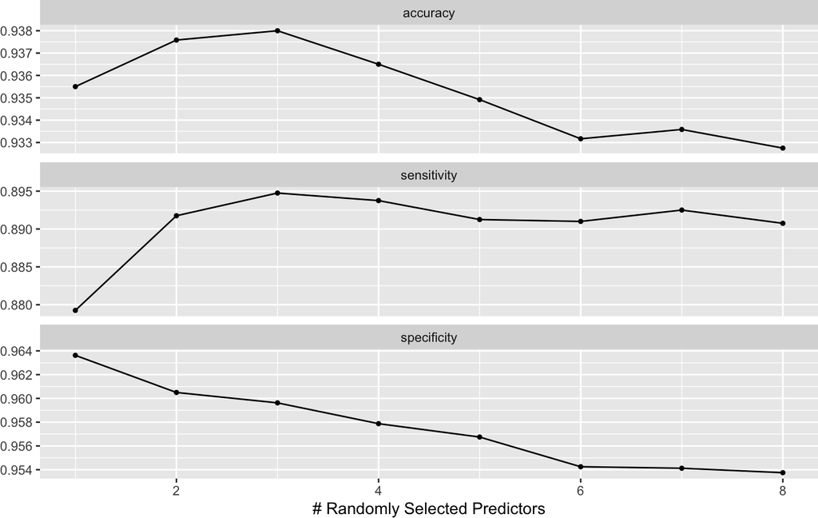

```r
autoplot(rf_res)
```

O melhor resultado da validação cruzada, considerando a acurácia como métrica:

```r
show_best(rf_res, metric = "accuracy", n = 1)
```

```
## # A tibble: 1 × 7
##    mtry .metric  .estimator  mean     n std_err .config
##   <int> <chr>    <chr>      <dbl> <int>   <dbl> <chr>
## 1     3 accuracy binary     0.938     5 0.00233 pre0_mod3_post0
```

## 8.5 Ajustando o modelo final (após *tuning*)

Vamos supor, por exemplo, que entre as quatro opções (regressão logística polinomial, LASSO, árvore de decisão e floresta aleatória), decidimos usar a regressão logística LASSO com melhor desempenho após a escolha do hiperparâmetro (*tuning*).

Precisamos então selecionar o modelo com o hiperparâmetro de melhor desempenho, usando a função `select_best()`:

```r
 best_acc <- select_best(logreglasso_res, metric = "accuracy")
 best_acc
```

```
## # A tibble: 1 × 2
##    penalty .config
##      <dbl> <chr>
## 1 1.29e-10 pre0_mod01_post0
```

```r
final_lasso_fit <- logreglasso_wf %>%
   finalize_workflow(best_acc) %>%
   last_fit(diabetes_split)
final_lasso_fit
```

```
## # Resampling results
## # Manual resampling
## # A tibble: 1 × 6
##   splits               id              .metrics .notes   .predictions .workflow
##   <list>               <chr>           <list>   <list>   <list>       <list>
## 1 <split [12000/3000]> train/test spl… <tibble> <tibble> <tibble>     <workflow>
```

Resultados no conjunto de teste:

```r
final_lasso_fit %>% collect_metrics()
```

```
## # A tibble: 3 × 4
##   .metric     .estimator .estimate .config
##   <chr>       <chr>          <dbl> <chr>
## 1 accuracy    binary         0.776 pre0_mod0_post0
## 2 roc_auc     binary         0.846 pre0_mod0_post0
## 3 brier_class binary         0.150 pre0_mod0_post0
```

Para o *workflow* final selecionado, podemos salvar todas as etapas de ajuste final (obtidas usando o conjunto de treinamento):

```r
fitted_wf <- extract_workflow(final_lasso_fit)
fitted_wf
```

```
## ══ Workflow [trained] ══════════════════════════════════════════════════════════
## Preprocessor: Formula
## Model: logistic_reg()
##
## ── Preprocessor ────────────────────────────────────────────────────────────────
## Diabetic ~ .
##
## ── Model ───────────────────────────────────────────────────────────────────────
##
## Call:  glmnet::glmnet(x = maybe_matrix(x), y = y, family = ~"binomial",      alpha = ~1)
##
##    Df  %Dev   Lambda
## 1   0  0.00 0.194600
## 2   1  2.25 0.177300
## 3   1  4.09 0.161500
```

[output cut: 46 more lines]

Obtenha valores preditos para os dados de teste:

```r
fitted_wf %>% augment(diabetes_test)
```

```
## # A tibble: 3,000 × 12
##    .pred_class .pred_1 .pred_0 Pregnancies PlasmaGlucose DiastolicBloodPressure
##    <fct>         <dbl>   <dbl>       <dbl>         <dbl>                  <dbl>
##  1 0            0.324    0.676           8            92                     93
##  2 0            0.107    0.893           1            85                     59
##  3 0            0.0389   0.961           0            67                     87
##  4 0            0.0624   0.938           1            72                     31
##  5 1            0.581    0.419           5           114                    101
##  6 0            0.288    0.712           8           117                     39
##  7 1            0.631    0.369           2            44                     81
##  8 0            0.136    0.864           0           119                     50
##  9 1            0.631    0.369           8           152                     83
## 10 0            0.170    0.830           2           118                     61
## # ℹ 2,990 more rows
## # ℹ 6 more variables: TricepsThickness <dbl>, SerumInsulin <dbl>, BMI <dbl>,
## #   DiabetesPedigree <dbl>, Age <dbl>, Diabetic <fct>
```

Resultados no conjunto de treinamento:

```r
fitted_wf %>%
  augment(diabetes_train) %>%
  metrics(truth = Diabetic, estimate = .pred_class)
```

```
## # A tibble: 2 × 3
##   .metric  .estimator .estimate
##   <chr>    <chr>          <dbl>
## 1 accuracy binary         0.790
## 2 kap      binary         0.507
```

Para obter as estimativas do modelo:

```r
final_lasso_fit %>%
  extract_fit_parsnip() %>%
  tidy() %>%
  kable(booktabs = TRUE)
```

| term | estimate | penalty |
| --- | --- | --- |
| (Intercept) | 8.4881010 | 0 |
| Pregnancies | -0.2752126 | 0 |
| PlasmaGlucose | -0.0084157 | 0 |
| DiastolicBloodPressure | -0.0108160 | 0 |
| TricepsThickness | -0.0224399 | 0 |
| SerumInsulin | -0.0038390 | 0 |
| BMI | -0.0514529 | 0 |
| DiabetesPedigree | -0.9734048 | 0 |
| Age | -0.0578455 | 0 |

## 8.6 Everything Everywhere All at Once

[figure not shown]

Podemos definir um conjunto de *workflows* e então avaliá-lo usando `tune_grid`.

```r
wf_tune_set <- workflow_set(preproc = list(rec1 = Diabetic ~ .,
                                           rec2 = diabetes_rec,
                                           rec1 = Diabetic ~ .,
                                           rec1 = Diabetic ~ .),
                            models = list(tree = tree_spec,
                                          logreg = logreg_spec,
                                          rf = rf_spec,
                                          lasso_log = logreglasso_spec),
                            cross = FALSE)
```

```r
set.seed(2024)
wf_tune_res <-  wf_tune_set %>%
  workflow_map(resamples = diabetes_folds,
               grid = 40,
               metrics = diabetes_metrics,
               control = control_grid(save_pred = TRUE))
```

```r
tune_results <- wf_tune_res %>%
  collect_metrics()
tune_results
```

```
## # A tibble: 273 × 9
##    wflow_id  .config        preproc model .metric .estimator  mean     n std_err
##    <chr>     <chr>          <chr>   <chr> <chr>   <chr>      <dbl> <int>   <dbl>
##  1 rec1_tree pre0_mod01_po… formula deci… accura… binary     0.913     5 0.00159
##  2 rec1_tree pre0_mod01_po… formula deci… sensit… binary     0.869     5 0.00393
##  3 rec1_tree pre0_mod01_po… formula deci… specif… binary     0.935     5 0.00306
##  4 rec1_tree pre0_mod02_po… formula deci… accura… binary     0.913     5 0.00159
##  5 rec1_tree pre0_mod02_po… formula deci… sensit… binary     0.869     5 0.00393
##  6 rec1_tree pre0_mod02_po… formula deci… specif… binary     0.935     5 0.00306
##  7 rec1_tree pre0_mod03_po… formula deci… accura… binary     0.913     5 0.00159
##  8 rec1_tree pre0_mod03_po… formula deci… sensit… binary     0.869     5 0.00393
##  9 rec1_tree pre0_mod03_po… formula deci… specif… binary     0.935     5 0.00306
## 10 rec1_tree pre0_mod04_po… formula deci… accura… binary     0.913     5 0.00159
## # ℹ 263 more rows
```

Vamos selecionar o *workflow* com melhor desempenho, considerando a acurácia:

```r
best_wf_id <- wf_tune_res %>%
  rank_results() %>%
  filter(.metric == "accuracy") %>%
  arrange(desc(mean)) %>%
  slice(1) %>%  # Select the best one
  pull(wflow_id)

best_wf_id
```

```
## [1] "rec1_rf"
```

Então, podemos extrair o melhor *workflow* da seguinte forma:

```r
best_workflow <- wf_tune_set %>%
  extract_workflow(best_wf_id)
```

Para finalizar o *workflow* selecionado fixando o hiperparâmetro com melhor desempenho:

```r
best_workflow_final <- best_workflow %>%
  finalize_workflow(
    wf_tune_res %>%
      extract_workflow_set_result(best_wf_id) %>%
      select_best(metric = "accuracy")
  )
best_workflow_final
```

```
## ══ Workflow ════════════════════════════════════════════════════════════════════
## Preprocessor: Formula
## Model: rand_forest()
##
## ── Preprocessor ────────────────────────────────────────────────────────────────
## Diabetic ~ .
##
## ── Model ───────────────────────────────────────────────────────────────────────
## Random Forest Model Specification (classification)
##
## Main Arguments:
##   mtry = 3
##   trees = 1000
##
## Engine-Specific Arguments:
##   importance = impurity
##
## Computational engine: ranger
```

```r
final_wf_fit <-
  best_workflow_final %>%
  last_fit(diabetes_split,
           metrics = diabetes_metrics)
final_wf_fit
```

```
## # Resampling results
## # Manual resampling
## # A tibble: 1 × 6
##   splits               id              .metrics .notes   .predictions .workflow
##   <list>               <chr>           <list>   <list>   <list>       <list>
## 1 <split [12000/3000]> train/test spl… <tibble> <tibble> <tibble>     <workflow>
```

Resultados no conjunto teste:

```r
final_wf_fit %>% collect_metrics()
```

```
## # A tibble: 3 × 4
##   .metric     .estimator .estimate .config
##   <chr>       <chr>          <dbl> <chr>
## 1 accuracy    binary         0.934 pre0_mod0_post0
## 2 sensitivity binary         0.89  pre0_mod0_post0
## 3 specificity binary         0.956 pre0_mod0_post0
```

Para o *workflow* final selecionado, salvamos todas as etapas de ajuste final (obtidas usando o conjunto de treinamento):

```r
fitted_wf <- extract_workflow(final_wf_fit)
fitted_wf
```

```
## ══ Workflow [trained] ══════════════════════════════════════════════════════════
## Preprocessor: Formula
## Model: rand_forest()
##
## ── Preprocessor ────────────────────────────────────────────────────────────────
## Diabetic ~ .
##
## ── Model ───────────────────────────────────────────────────────────────────────
## Ranger result
##
## Call:
##  ranger::ranger(x = maybe_data_frame(x), y = y, mtry = min_cols(~3L,      x), num.trees = ~1000, importance = ~"impurity", num.threads = 1,      verbose = FALSE, seed = sample.int(10^5, 1), probability = TRUE)
##
## Type:                             Probability estimation
## Number of trees:                  1000
## Sample size:                      12000
## Number of independent variables:  8
## Mtry:                             3
## Target node size:                 10
## Variable importance mode:         impurity
## Splitrule:                        gini
## OOB prediction error (Brier s.):  0.04835691
```

```r
saveRDS(fitted_wf, "diabetes_rf_modelo.rds")
```

Valores preditos para o conjunto de teste:

```r
final_wf_fit %>% augment()
```

```
## # A tibble: 3,000 × 10
##    Diabetic .pred_class Pregnancies PlasmaGlucose DiastolicBloodPressure
##    <fct>    <fct>             <dbl>         <dbl>                  <dbl>
##  1 0        0                     8            92                     93
##  2 0        0                     1            85                     59
##  3 0        0                     0            67                     87
##  4 0        0                     1            72                     31
##  5 1        1                     5           114                    101
##  6 0        0                     8           117                     39
##  7 1        1                     2            44                     81
##  8 0        0                     0           119                     50
##  9 0        0                     8           152                     83
## 10 1        1                     2           118                     61
## # ℹ 2,990 more rows
## # ℹ 5 more variables: TricepsThickness <dbl>, SerumInsulin <dbl>, BMI <dbl>,
## #   DiabetesPedigree <dbl>, Age <dbl>
```

*Workflow* final:

```r
fitted_wf %>%
  extract_fit_parsnip()
```

```
## parsnip model object
##
## Ranger result
##
## Call:
##  ranger::ranger(x = maybe_data_frame(x), y = y, mtry = min_cols(~3L,      x), num.trees = ~1000, importance = ~"impurity", num.threads = 1,      verbose = FALSE, seed = sample.int(10^5, 1), probability = TRUE)
##
## Type:                             Probability estimation
## Number of trees:                  1000
## Sample size:                      12000
## Number of independent variables:  8
## Mtry:                             3
## Target node size:                 10
## Variable importance mode:         impurity
## Splitrule:                        gini
## OOB prediction error (Brier s.):  0.04835691
```

Visualização da importância dos preditores:

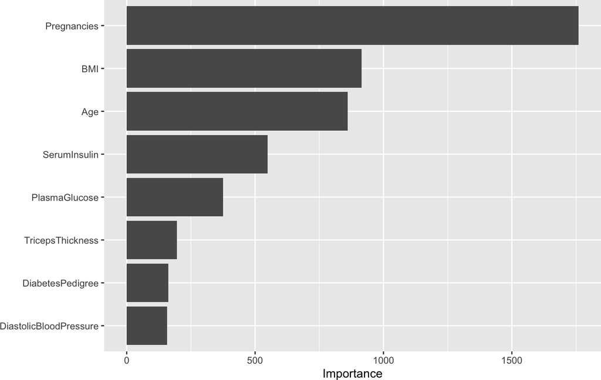

```r
library(vip)
final_wf_fit %>%
  extract_fit_parsnip() %>%
  vip(num_features = 10)
```

# 9 Predição para novos dados

Com o modelo final escolhido e salvo, podemos utilizá-lo na predição de `Diabetic` quando tivermos acesso às variáveis preditoras de novos pacientes.

Para carregar o modelo salvo:

```r
modelo_final <- readRDS("diabetes_rf_modelo.rds")
```

Preparando os dados de dois novos pacientes, por exemplo:

```r
novos_pacientes <- tibble(Pregnancies = c(1, 2),
                        PlasmaGlucose = c(100, 180),
                        DiastolicBloodPressure = c(30, 80),
                        TricepsThickness = c( 15, 42),
                        SerumInsulin = c(39, 180),
                        BMI = c(25, 39),
                        DiabetesPedigree = c(0.15, 0.60),
                        Age = c(30, 50))

novos_pacientes
```

```
## # A tibble: 2 × 8
##   Pregnancies PlasmaGlucose DiastolicBloodPressure TricepsThickness SerumInsulin
##         <dbl>         <dbl>                  <dbl>            <dbl>        <dbl>
## 1           1           100                     30               15           39
## 2           2           180                     80               42          180
## # ℹ 3 more variables: BMI <dbl>, DiabetesPedigree <dbl>, Age <dbl>
```

e acrescentar as colunas com as predições (tanto de classe quanto de probabilidade para cada classe):

```r
bind_cols(
  novos_pacientes,
  predict(modelo_final, new_data = novos_pacientes, type = "class"),
  predict(modelo_final, new_data = novos_pacientes, type = "prob")
)
```

```
## # A tibble: 2 × 11
##   Pregnancies PlasmaGlucose DiastolicBloodPressure TricepsThickness SerumInsulin
##         <dbl>         <dbl>                  <dbl>            <dbl>        <dbl>
## 1           1           100                     30               15           39
## 2           2           180                     80               42          180
## # ℹ 6 more variables: BMI <dbl>, DiabetesPedigree <dbl>, Age <dbl>,
## #   .pred_class <fct>, .pred_1 <dbl>, .pred_0 <dbl>
```

# Referências

Hastie, Trevor, Robert Tibshirani, and Jerome Friedman. 2001. *The Elements of Statistical Learning*. Springer Series in Statistics. Springer New York Inc.

James, Gareth, Daniela Witten, Trevor Hastie, and Robert Tibshirani. 2013. *An Introduction to Statistical Learning: With Applications in r*. Springer. https://www.statlearning.com.

Kuhn, M., and J. Silge. 2022. *Tidy Modeling with r*. O’Reilly Media. https://www.tmwr.org.

Sharika, Tarin Sultana, Abdullah Al Farabe, Ghalib Ashraf, Nahian Raonak, and Amitabha Chakrabarty. 2021. “A Supervised Learning Approach by Machine Learning Algorithms to Predict Diabetes Mellitus (DM) Risk Score.” In *Soft Computing: Theories and Applications*. Springer Singapore. https://doi.org/10.1007/978-981-16-1696-9_27.